# **Cyber Crimes in India**

Project Report

Jasmeen Sharma

# Police Case Disposal

## Introduction

The core duty of the police service is to protect the public by detecting and preventing crime.  
Police powers can be grouped into three categories:

Powers to investigate crime. This includes a range of powers to collect evidence needed to identify suspects and support their fair and effective trial.  
Powers to prevent crime. This includes a range of powers to maintain public order, prevent anti-social behaviour and manage known offenders/ suspects.  
Powers to ‘dispose’ of criminal cases. These powers allow police officers to dispose of criminal cases outside of court or charge suspects so they can be prosecuted.

Various crimes that are being registered and investigated by different law enforcement agencies are broadly grouped under the following categories for statistical information system.  
**Broad classification of crimes Crimes under I.T. Act:**  
1.Tampering computer source documents  
2.Computer Related Offences  
3.Cyber Terrorism  
4.Publication/transmission of obscene / sexually explicit act in electronic form  
5.Decryption of Information  
6.Un-authorized access/attempt to access to protected computer system  
7.Abetment to Commit Offences  
8.Attempt to Commit Offences  
9.Other Sections of IT Act

**Crimes under the Indian Penal Code(IPC)**  
1.Abetment of Suicide (Online)  
2.Cyber Stalking/Bullying of Women/Children  
3.Data theft  
4.Fraud  
5.Credit Card/Debit Card  
6.ATMs  
7.Online Banking Fraud  
8.OTP Frauds  
9.Others  
10.Cheating  
11.Forgery  
12.Defamation/Morphing  
13.Fake Profile  
14.Counterfeiting  
15.Currency  
16.Stamps  
17.Cyber Blackmailing/Threatening  
18.Fake News on Social Media  
19.Other Offences

**Crimes under the Special and Local Laws (SLL)**  
1.Gambling Act (Online Gambling)  
2.Lotteries Act (Online Lotteries)  
3.Copy Right Act  
4.Trade Marks Act  
5.Other SLL Crimes

## Police Disposal of Cyber Crime Cases (Crime Head-wise) : Statistics and Data

### Visualization

Total Cases Investigated year2021

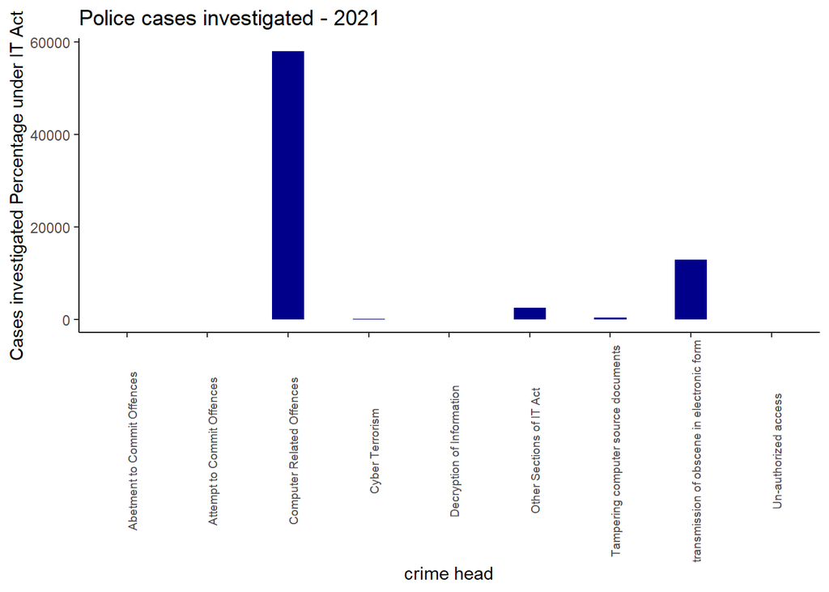

The above figure shows that under IT Act of computer related offences are highest with 78.457 %.

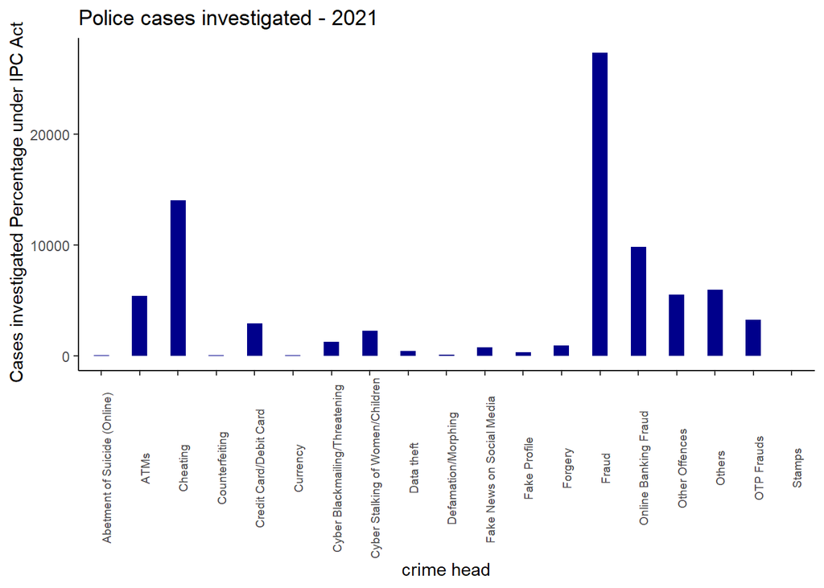

The above figure shows that cases investigated by Police “Under IPC Act” of Fraud are highest with 51.587 %.

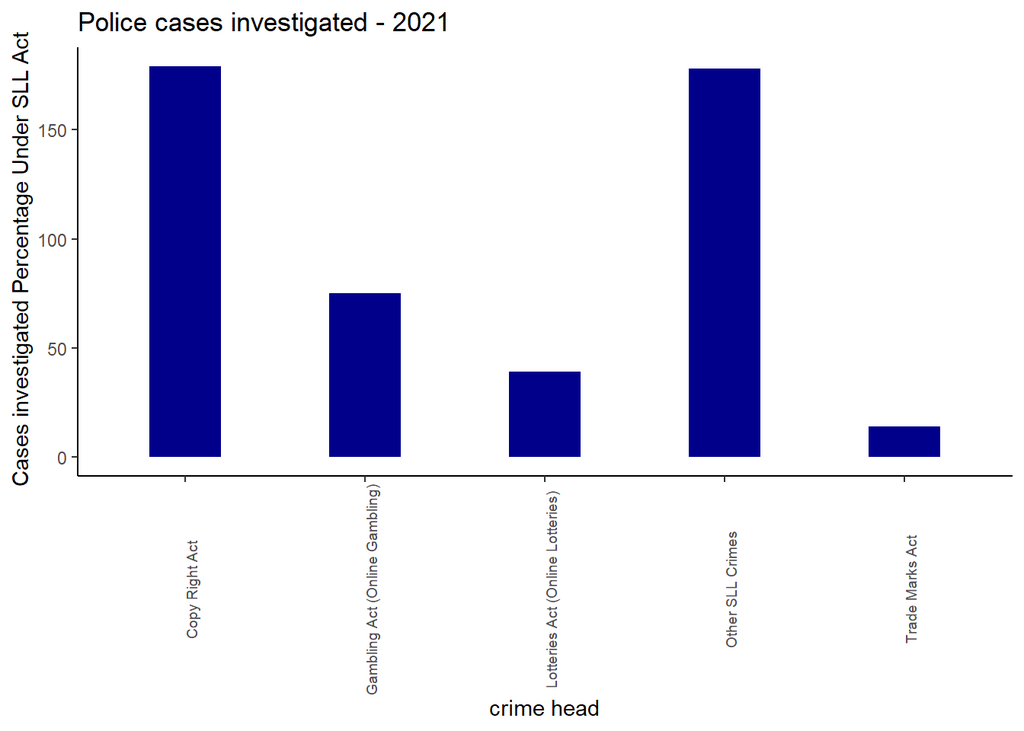

The above figure shows that cases investigated by Police “Under SLL Act” of Copy Right Act are highest with 36.907 %.

year2021

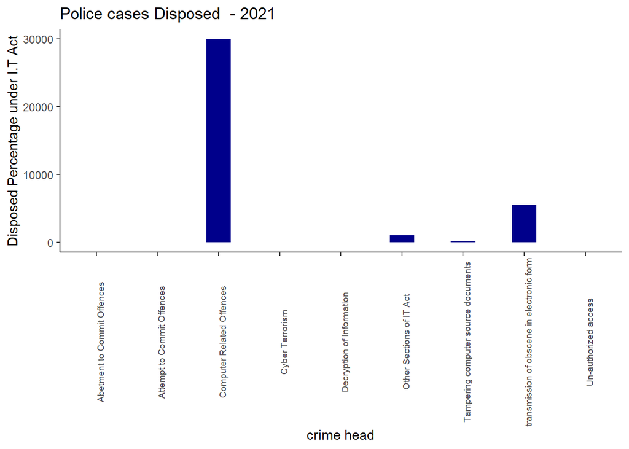

The above figure shows that cases Disposed under IT Act of computer related offences are highest with 81.767 %.

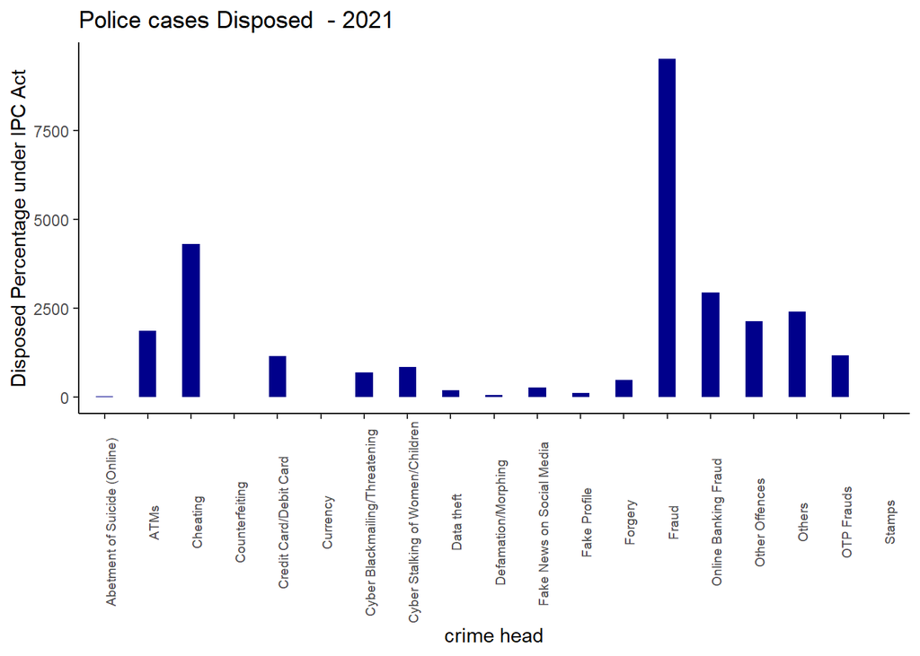

The above figure shows that cases Disposed by Police “Under IPC Act” of Fraud are highest with 51.127 %.

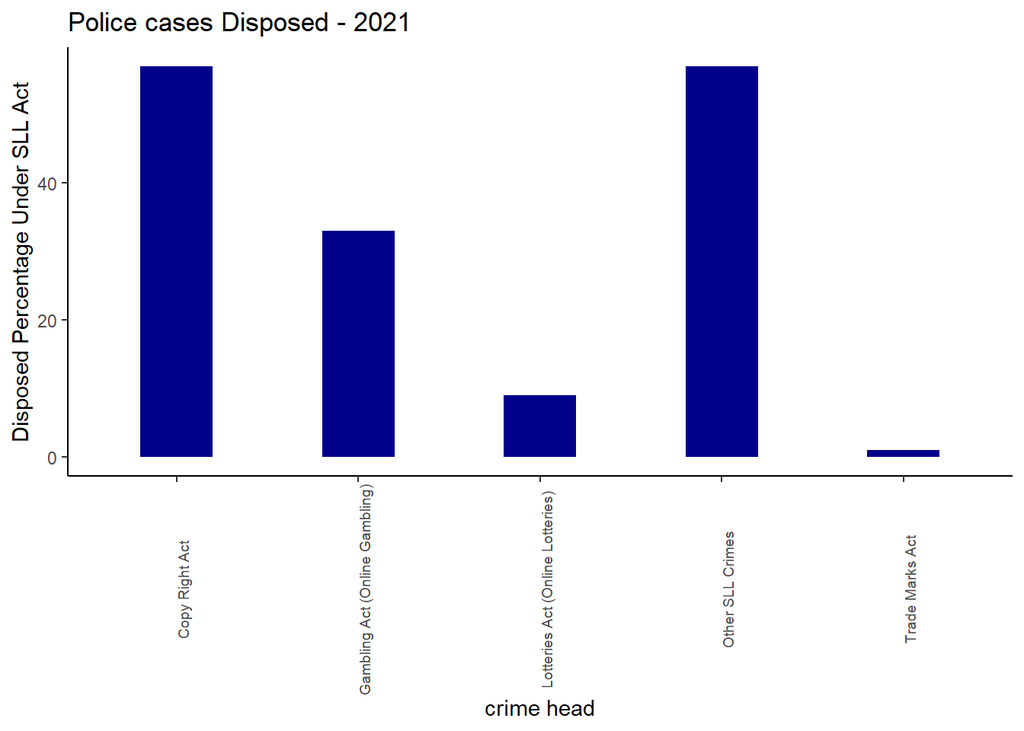

The above figure shows that cases Disposed by Police “Under SLL Act” of Copy Right Act and Other SLL Crimes are highest with 36.306 %.

Total Cases Pending year2021

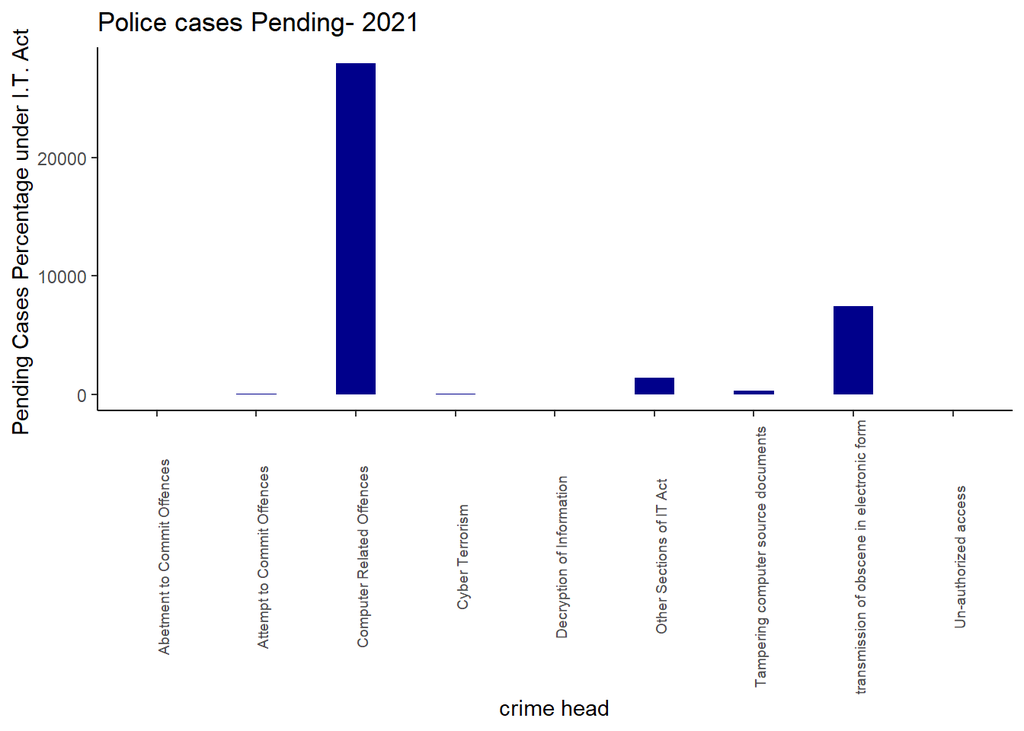

The above figure shows that Cases pending under IT Act of computer related offences are highest with 75.194 %.

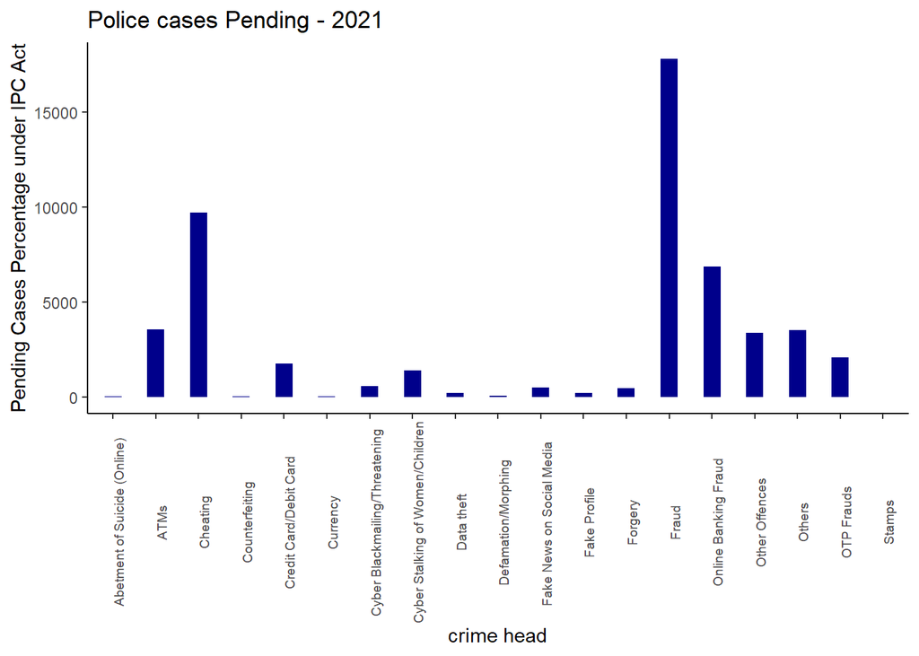

The above figure shows that cases pending by Police “Under IPC Act” of Fraud are highest with 51.853 %.

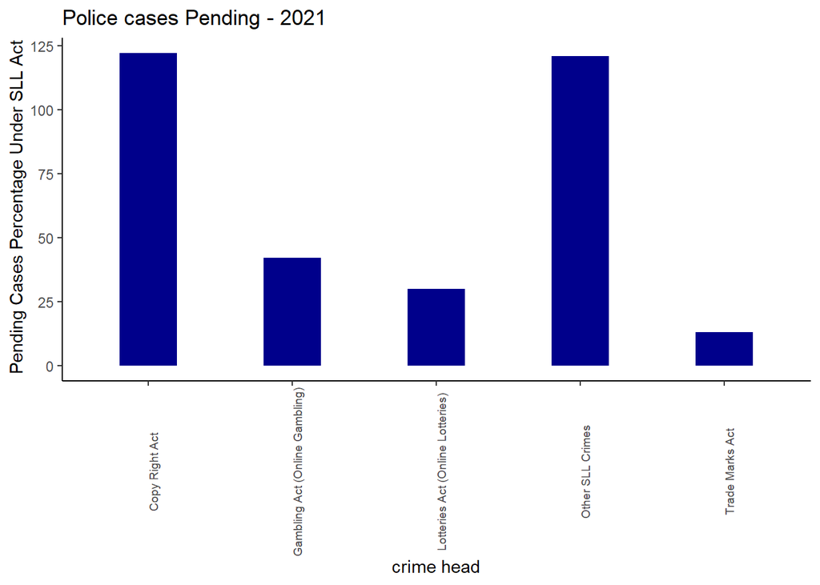

```r
Plot_cases_pending_SLL_21 = bardiag(df21[31:35,], ax = df21$Crime_Head[31:35],
                                    ay = df21$Cases_Pending_21[31:35],     "blue4","Police cases Pending - 2021", df21$cases_pending_per[31:35],
                                    "crime head",
                                    " Pending Cases Percentage Under SLL Act" )
Plot_cases_pending_SLL_21
```

The above figure shows that cases pending by Police “Under SLL Act” of Copy Right Act are highest with 37.195 %.

Year2020

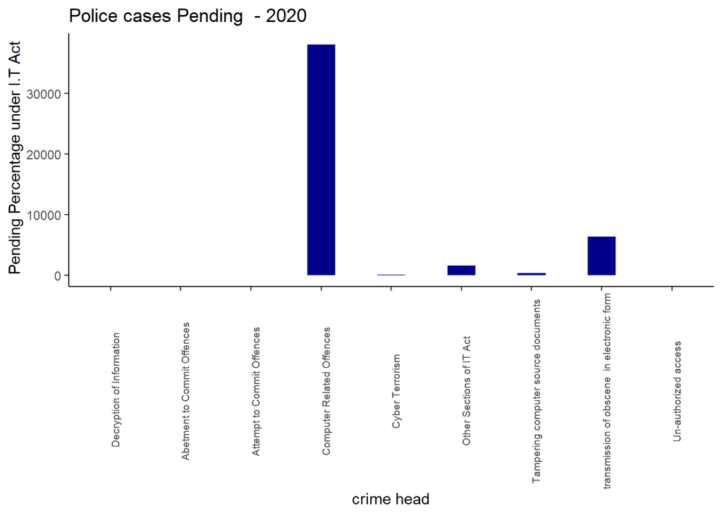

The above figure shows that Cases pending under IT Act of computer related offences are highest with 81.926% %.

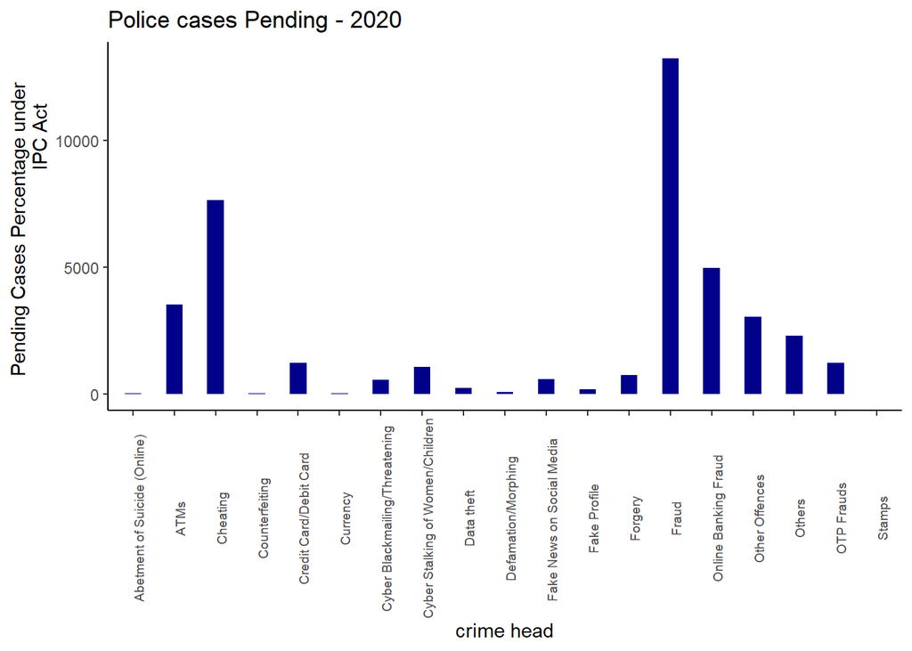

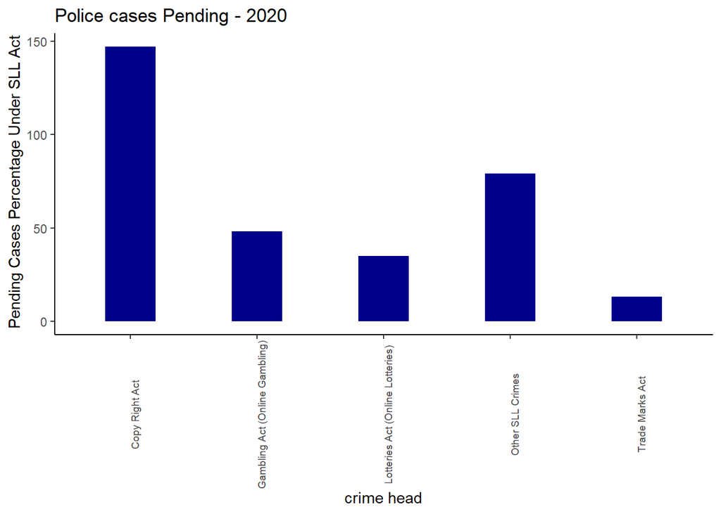

[figure not shown]

```r
rm(list = ls())
library(readxl)
dfU21 = read.csv("st2021.csv")
dfU21 = cbind(dfU21, Rates_States=(dfU21$Cases_Disposed[1:28])/(dfU21$Mid_Year_Projected_Population[1:28]))
statewise = ggplot(data = dfU21, aes(x = States , y = Rates_States))+geom_bar(stat = "identity", fill = "blue4")
statewise
```

## Total Cyber Crimes for Investigation and their Disposal by Police

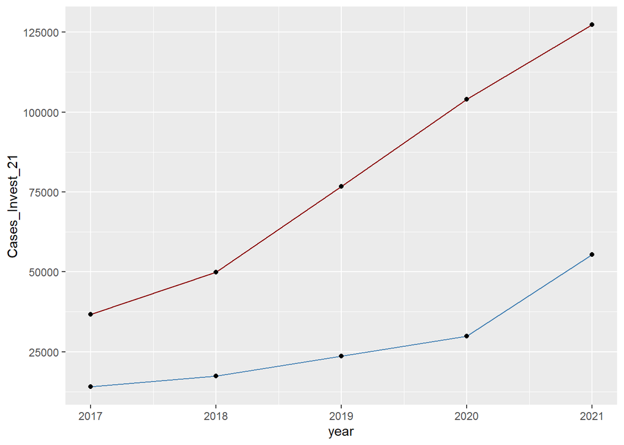

Upper line shows Total Cyber Crimes for Investigation and line shows their disposal. This graph shows Total Cyber Crimes for Investigation and their Disposal by Police .

##Testing location(crimehead-wise)

```
##
##  Kruskal-Wallis rank sum test
##
## data:  data[, seq(1, 17, 4)]
## Kruskal-Wallis chi-squared = 0.29403, df = 4, p-value = 0.9902
```

Since p-value > 0.05,for Kruskal Wallis test ,the result is not significant .i.e we fail to reject null hypothesis.Therefore there is no significant change in the location throught the years 2017-2021.Hence we conclude that cases investigated crime head wise are statistically same for different years.

```
##
##  Kruskal-Wallis rank sum test
##
## data:  data[, seq(2, 18, 4)]
## Kruskal-Wallis chi-squared = 0.57253, df = 4, p-value = 0.9661
```

Since p-value > 0.05,for Kruskal Wallis test ,the result is not significant .i.e we fail to reject null hypothesis.Therefore there is no significant change in the location throught the years 2017-2021.Hence we conclude that cases true but insufficient evidence crime head wise are statistically same for different years.

```
##
##  Kruskal-Wallis rank sum test
##
## data:  data[, seq(3, 19, 4)]
## Kruskal-Wallis chi-squared = 0.47127, df = 4, p-value = 0.9762
```

Since p-value > 0.05,for Kruskal Wallis test ,the result is not significant  
.i.e we fail to reject null hypothesis.Therefore there is no significant change  
in the location throught the years 2017-2021.Hence we conclude that cases  
disposed crime head wise are statistically same for different years.

```
##
##  Kruskal-Wallis rank sum test
##
## data:  data[, seq(4, 20, 4)]
## Kruskal-Wallis chi-squared = 0.80944, df = 4, p-value = 0.9372
```

Since p-value > 0.05,for Kruskal Wallis test ,the result is not significant  
.i.e we fail to reject null hypothesis.Therefore there is no significant change  
in the location throught the years 2017-2021.Hence we conclude that cases  
pending crime head wise are statistically same for different years.

##Testing variability and location(state-wise)

```r
rm(list = ls())
stdata = read.csv("statewise.csv")
library(car)
rownames(stdata) = stdata$States
stdata = stdata[-1]
stcasesinvest = stdata[seq(1,17,4)]
stinvest = unlist(stcasesinvest)
year = rep( c("y21","y20", "y19", "y18", "y17" ),each = 28 )
st_casesinvest = data.frame(stinvest, year)
leveneTest(stinvest~as.factor(year), st_casesinvest )
```

|  | Df | F value | Pr(>F) |
| --- | --- | --- | --- |
| group | 4 | 1.69383 | 0.1550215 |
|  | 135 | NA | NA |

Since p-value > 0.05 , for levene’s test hence the test is not significant i.e. we failed to reject null hypothesis.  
Therefore there is no significant variability in the data through 2017-21  
Now testing for equality in location using Kruskal Wallis Test

```
##
##  Kruskal-Wallis rank sum test
##
## data:  stinvest by as.factor(year)
## Kruskal-Wallis chi-squared = 5.1332, df = 4, p-value = 0.2739
```

Since p-value > 0.05 , for Kruskal Wallis test, the result is not significant i.e. we failed to reject null hypothesis.  
Therefore there is no significant change in the locations throughout the years 2017-21 Hence, from both the tests,Since there is no significant difference in location and variability in different years. Hence we conclude that cases investigated are statistically same in terms of location and variability for different crimes.

|  | Df | F value | Pr(>F) |
| --- | --- | --- | --- |
| group | 4 | 1.859156 | 0.1212289 |
|  | 135 | NA | NA |

Since p-value > 0.05 , for levene’s test hence the test is not significant i.e. we failed to reject null hypothesis. Therefore there is no significant variability in the data through 2017-21 Now testing for equality in location using Kruskal Wallis Test

```
##
##  Kruskal-Wallis rank sum test
##
## data:  sttrue by as.factor(year)
## Kruskal-Wallis chi-squared = 2.7508, df = 4, p-value = 0.6004
```

Since p-value > 0.05 , for Kruskal Wallis test, the result is not significant i.e. we failed to reject null hypothesis. Therefore there is no significant change in the locations throughout the years 2017-21 Hence, from both the tests,Since there is no significant difference in location and variability in different years. Hence we conclude that cases true but insufficient evidence are statistically same in terms of location and variability for different crimes.

[output not shown]

Since p-value > 0.05 , for levene’s test hence the test is not significant i.e. we failed to reject null hypothesis. Therefore there is no significant variability in the data through 2017-21

[output not shown]

Since p-value > 0.05 , for Kruskal Wallis test, the result is not significant i.e. we failed to reject null hypothesis. Therefore there is no significant change in the locations throughout the years 2017-21 Hence, from both the tests,Since there is no significant difference in location and variability in different years. Hence we conclude that cases Disposed are statistically same in terms of location and variability for different crimes.

[output not shown]

Since p-value > 0.05 , for levene’s test hence the test is not significant  
i.e. we failed to reject null hypothesis. Therefore there is no significant variability in the data through 2017-21

[output not shown]

Since p-value > 0.05 , for Kruskal Wallis test, the result is not significant  
i.e. we failed to reject null hypothesis. Therefore there is no significant  
change in the locations throughout the years 2017-21 Hence, from both the tests,Since there is no significant difference in location and variability in different years. Hence we conclude that cases pending are statistically same in terms of location and variability for different crimes.

##Wilcoxn signed rank test

Wilcoxn signed rank test  
The Wilcoxn test is a non parametric alternative to the t-test for comparing two means  
The goal of the test is to determine if two or more sets of pairs are different from one another in a statistically significant manner  
Model assume the pairs in the data come from dependent populations

```r
wilcox.test( stdata$Cases_Invest_17, stdata$Cases_Invest_21, paired = TRUE )
```

```
##
##  Wilcoxon signed rank exact test
##
## data:  stdata$Cases_Invest_17 and stdata$Cases_Invest_21
## V = 0, p-value = 7.451e-09
## alternative hypothesis: true location shift is not equal to 0
```

The p-value < 0.05. We conclude that the cases investigated in year 2017 are significantly different from cases investigated in year 2021.

```r
wilcox.test( stdata$Cases_Disposed_17, stdata$Cases_Disposed_21, paired = TRUE )
```

```
##
##  Wilcoxon signed rank test with continuity correction
##
## data:  stdata$Cases_Disposed_17 and stdata$Cases_Disposed_21
## V = 0, p-value = 5.934e-06
## alternative hypothesis: true location shift is not equal to 0
```

The p-value < 0.05. We conclude that the cases Disposed in year 2017 are significantly different from cases Disposed in year 2021.

```r
wilcox.test( stdata$Cases_Pending_17, stdata$Cases_Pending_21, paired = TRUE )
```

```
##
##  Wilcoxon signed rank exact test
##
## data:  stdata$Cases_Pending_17 and stdata$Cases_Pending_21
## V = 0, p-value = 7.451e-09
## alternative hypothesis: true location shift is not equal to 0
```

The p-value < 0.05. We conclude that the cases pending in year 2017 are significantly different from cases pending in year 2021.

```r
wilcox.test( stdata$True_cases.but.insufficient.evidence_17, stdata$True_cases.but.insufficient.evidence_21, paired = TRUE )
```

```
##
##  Wilcoxon signed rank test with continuity correction
##
## data:  stdata$True_cases.but.insufficient.evidence_17 and stdata$True_cases.but.insufficient.evidence_21
## V = 23.5, p-value = 7.358e-05
## alternative hypothesis: true location shift is not equal to 0
```

```r
rm(list = ls())
library(factoextra)
library(cluster)
data = read.csv("yearwisecluster.csv")
rownames(data) = data$Crime_Head
data = data[-1]
data.scaled = scale(data)
```

###Agglomerative HCA: Algorithm: Operates by successive merger of cases 1.Begin with N clusters each containing single cases. 2.At each stage, we merge the two most similar groups to form a new cluster.Thus reducing the no. of clusters to (N-1) 3.Continue till all subgroups are fuse to form a single cluster.

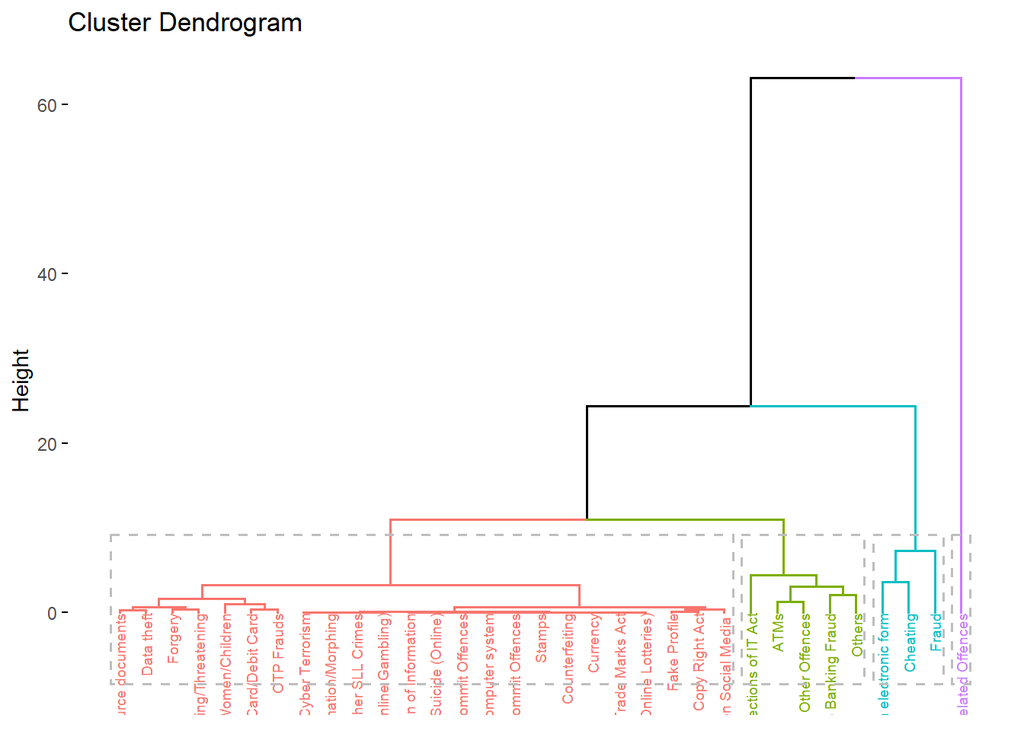

###Divisive HCA  
1.Divisive method operates by successive splitting of group.  
2.Initially starts with a single group(i.e.one single cluster)  
3.Group is divided into two groups  
4.Continue till there are n groups each with a single object.

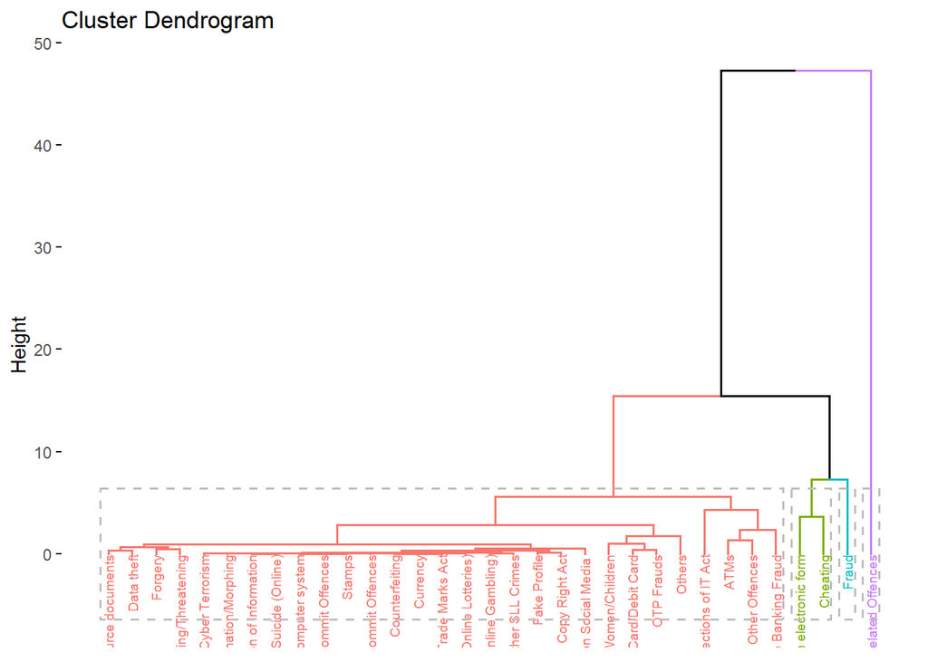

```r
res.diana <- diana(x = data, # data matrix
stand = TRUE, # standardize the data
metric = "euclidean")
fviz_dend(res.diana,k = 4,color_labels_by_k = TRUE,cex = 0.5,rect = TRUE)
```